# An Analysis of Car Accidents across the US

#### By Harleen Kaur (CMSC 320, Spring 2021)

### 1. Introduction

About 6 million car accidents take place across the US every year and this is just the US alone. About 3 million of them are injured during the accident. For just one country this is a very high statistic thus it becomes important to understand what is causing these accidents and the factors that affect how severe the accident might be in order for someone to get injured. Doing so can provide us some insight and might even help save someones life.

During the course of this project, I try to look at a subset of the car accidents that have occured across the US and try to understand if there are any factors that influence the amount of accidents that are occuring or the seriousness of the accident itself. Some of these include population, location, as well as weather when the accident occured.

In the course of the project I will:

1. Collect data from online sources
2. Clean up the data collected
3. Create visualizations and analyze the data
4. Apply machine learning

To begin with we need to first import the multiple libraries that python offers so that we can use them throughout the project.

```python
import pandas as pd
import datetime
import numpy as np
from matplotlib import pyplot as plt
```

The pandas library will be important to hold our dataset as a dataframe. The datetime will help us represent some times as datetime objects so that we can do arithmetic operations on them. numpy is a helpful library for most arithmetic operations and matplotlib is the main library used to create plots.

### 2. Collecting Data

The dataset that I found is from Kaggle and it details about 3 million records of car accidents that occured across the US in 49 states. The current version of the dataset contains accidents from February 2016 to December 2020 and can be found here: https://www.kaggle.com/sobhanmoosavi/us-accidents/version/9

Once I had downloaded the dataset I needed to import it into a pandas DataFrame. Since the dataset is in a csv file it was extremely easy to do this as pandas has a built in function called read_csv for this purpose.

```python
df = pd.read_csv('US_Accidents_Dec20_Updated.csv')
```

Now let's take a look at some of the first couple of records in the data

```python
df.head()
```

|  | ID | Severity | Start_Time | End_Time | Start_Lat | Start_Lng | End_Lat | End_Lng | Distance(mi) | Description | ... | Roundabout | Station | Stop | Traffic_Calming | Traffic_Signal | Turning_Loop | Sunrise_Sunset | Civil_Twilight | Nautical_Twilight | Astronomical_Twilight |
| --- | --- | --- | --- | --- | --- | --- | --- | --- | --- | --- | --- | --- | --- | --- | --- | --- | --- | --- | --- | --- | --- |
| 0 | A-1 | 2 | 2019-05-21 08:29:55 | 2019-05-21 09:29:40 | 34.808868 | -82.269157 | 34.808868 | -82.269157 | 0.0 | Accident on Tanner Rd at Pennbrooke Ln. | ... | False | False | False | False | False | False | Day | Day | Day | Day |
| 1 | A-2 | 2 | 2019-10-07 17:43:09 | 2019-10-07 19:42:50 | 35.090080 | -80.745560 | 35.090080 | -80.745560 | 0.0 | Accident on Houston Branch Rd at Providence Br... | ... | False | False | False | False | False | False | Day | Day | Day | Day |
| 2 | A-3 | 2 | 2020-12-13 21:53:00 | 2020-12-13 22:44:00 | 37.145730 | -121.985052 | 37.165850 | -121.988062 | 1.4 | Stationary traffic on CA-17 from Summit Rd (CA... | ... | False | False | False | False | False | False | Night | Night | Night | Night |
| 3 | A-4 | 2 | 2018-04-17 16:51:23 | 2018-04-17 17:50:46 | 39.110390 | -119.773781 | 39.110390 | -119.773781 | 0.0 | Accident on US-395 Southbound at Topsy Ln. | ... | False | False | False | False | True | False | Day | Day | Day | Day |
| 4 | A-5 | 3 | 2016-08-31 17:40:49 | 2016-08-31 18:10:49 | 26.102942 | -80.265091 | 26.102942 | -80.265091 | 0.0 | Accident on I-595 Westbound at Exit 4 / Pine I... | ... | False | False | False | False | True | False | Day | Day | Day | Day |

5 rows × 47 columns

Clearly this data contains a lot of information, some of it might not be hepful so we will clean some of it up for later.

```python
len(df)
```

```
2906610
```

However the issue with this dataset is that it contains nearly 3 million records (as displayed above). Since every piece of code would take a large amount of time to run on 3 million records, I thought it would be a good idea to take a smaller portion of the dataset. The pandas library has a sample function that allows us to take a random sample from the dataset. I decided to use this function because it gives every record in the large dataset an equal probability to be picked in the sample. This reduces the chance of bias.

```python
us_accidents = df.sample(250000)
```

Now we have a smaller sample of data to work with and explore which looks as follows:

```python
us_accidents
```

|  | ID | Severity | Start_Time | End_Time | Start_Lat | Start_Lng | End_Lat | End_Lng | Distance(mi) | Description | ... | Roundabout | Station | Stop | Traffic_Calming | Traffic_Signal | Turning_Loop | Sunrise_Sunset | Civil_Twilight | Nautical_Twilight | Astronomical_Twilight |
| --- | --- | --- | --- | --- | --- | --- | --- | --- | --- | --- | --- | --- | --- | --- | --- | --- | --- | --- | --- | --- | --- |
| 476377 | A-476378 | 2 | 2018-04-26 22:46:11 | 2018-04-26 23:15:48 | 38.637547 | -121.282394 | 38.637547 | -121.282394 | 0.000 | Accident on Fair Oaks Blvd at Southcliff Dr. | ... | False | False | False | False | False | False | Night | Night | Night | Night |
| 594425 | A-594426 | 2 | 2018-11-04 10:39:23 | 2018-11-04 11:24:04 | 35.478474 | -97.565781 | 35.478474 | -97.565781 | 0.000 | Accident on 10th St at May Ave. | ... | False | False | False | False | True | False | Day | Day | Day | Day |
| 652348 | A-652349 | 3 | 2020-06-03 11:16:57 | 2020-06-03 13:02:32 | 26.783161 | -80.099022 | 26.783161 | -80.099022 | 0.000 | Lane blocked due to accident on I-95 Southboun... | ... | False | False | False | False | False | False | Day | Day | Day | Day |
| 115241 | A-115242 | 2 | 2020-02-14 17:15:50 | 2020-02-14 18:21:19 | 47.439583 | -122.321411 | 47.439583 | -122.321411 | 0.000 | Left lane blocked due to accident on WA-509 De... | ... | False | False | False | False | False | False | Day | Day | Day | Day |
| 2212335 | A-2212336 | 2 | 2019-08-17 19:05:35 | 2019-08-17 23:05:35 | 43.895190 | -124.118010 | 43.894714 | -124.118155 | 0.034 | At Booth Rd - Accident. | ... | False | False | False | False | False | False | Day | Day | Day | Day |
| ... | ... | ... | ... | ... | ... | ... | ... | ... | ... | ... | ... | ... | ... | ... | ... | ... | ... | ... | ... | ... | ... |
| 744038 | A-744039 | 2 | 2020-12-27 18:20:15 | 2020-12-27 20:42:33 | 45.289324 | -93.764694 | 45.264544 | -93.716474 | 2.903 | Incident on I-94 EB near CR-8 Drive with caution. | ... | False | False | False | False | False | False | Night | Night | Night | Day |
| 244804 | A-244805 | 2 | 2016-08-04 16:14:35 | 2016-08-04 16:59:35 | 33.965546 | -118.232758 | 33.965546 | -118.232758 | 0.000 | Slow traffic due to accident on Alameda St in ... | ... | False | False | False | False | False | False | Day | Day | Day | Day |
| 2053172 | A-2053173 | 2 | 2019-04-20 15:49:18 | 2019-04-20 16:19:04 | 40.071335 | -74.957825 | 40.043810 | -75.002890 | 3.049 | Between Street Rd/Exit 37 and Academy Rd/Exit ... | ... | False | False | False | False | False | False | Day | Day | Day | Day |
| 478058 | A-478059 | 2 | 2018-01-19 19:01:07 | 2018-01-19 19:30:55 | 34.648170 | -81.860092 | 34.648170 | -81.860092 | 0.000 | Accident on SC-146 Cross Anchor Rd at SC-56. | ... | False | False | False | False | False | False | Night | Night | Night | Day |
| 2602488 | A-2602489 | 2 | 2020-12-08 18:30:00 | 2020-12-08 20:05:25 | 30.467305 | -86.927415 | 30.467461 | -86.925533 | 0.113 | Incident on GORDON EVANS RD near TOPAZ CIR Dri... | ... | False | False | False | False | False | False | Night | Night | Night | Night |

250000 rows × 47 columns

Since I wanted to explore the relationship between the population of a state and the number of accidents occuring in the state, I needed to get data about the population of each state and store it in a different dataframe. In order to do this I decided to scrape this website https://simple.wikipedia.org/wiki/List_of_U.S._states_by_population which has a table of populations per state.

In order to scrape the data, I used the requests library as well as BeautifulSoup to read the html version of the page and extract the table from it. To learn more about BeatifulSoup, here is the documentation that helped me as it has example code that explains the functions really well. https://www.crummy.com/software/BeautifulSoup/bs4/doc/

```python
import requests
from bs4 import BeautifulSoup
```

```python
#Getting the url to extract text from
url = requests.get('https://simple.wikipedia.org/wiki/List_of_U.S._states_by_population')

#Extracting text from the page and using BeautifulSoup to read in the data
text = url.content
root = BeautifulSoup(text, 'html.parser')
```

```python
#Trying to find the table
table = root.find("table")
table = table.prettify()

#Using pandas to read in the all the tables on the page
state_population = pd.read_html(table, flavor='bs4')
#We only need the first table in the list
state_population = state_population[0]
```

```python
state_population
```

|  | Rank in states & territories, 2019 | Rank in states & territories, 2010 | State | Population estimate, July 1, 2019 [2] | Census population, April 1, 2010 [3] | Percent change, 2010–2019 [note 1] | Absolute change, 2010-2019 | Total seats in the U.S. House of Representatives , 2013–2023 | Estimated population per electoral vote, 2019 [note 2] | Estimated population per House seat, 2019 | Census population per House seat, 2010 | Percent of the total U.S. population, 2018 [note 3] |
| --- | --- | --- | --- | --- | --- | --- | --- | --- | --- | --- | --- | --- |
| 0 | 1 | 1 | California | 39512223 | 37254523 | 6.1% | +2,257,700 | 53 | 718404 | 745514 | 702885 | 11.96% |
| 1 | 2 | 2 | Texas | 28995881 | 25145561 | 15.3% | +3,850,320 | 36 | 763050 | 805441 | 698503 | 8.68% |
| 2 | 3 | 4 | Florida | 21477737 | 18801310 | 14.2% | +2,676,427 | 27 | 740611 | 795472 | 696468 | 6.44% |
| 3 | 4 | 3 | New York | 19453561 | 19378102 | 0.4% | +75,459 | 27 | 670812 | 720502 | 717707 | 5.91% |
| 4 | 5 | 6 | Pennsylvania | 12801989 | 12702379 | 0.8% | +99,610 | 18 | 640099 | 711222 | 705715 | 3.87% |
| 5 | 6 | 5 | Illinois | 12671821 | 12830632 | -1.2% | −158,811 | 18 | 633591 | 703990 | 712864 | 3.85% |
| 6 | 7 | 7 | Ohio | 11689100 | 11536504 | 1.3% | +152,596 | 16 | 649394 | 730569 | 721032 | 3.53% |
| 7 | 8 | 9 | Georgia | 10617423 | 9687653 | 9.6% | +929,770 | 14 | 663589 | 758387 | 691975 | 3.18% |
| 8 | 9 | 10 | North Carolina | 10488084 | 9535483 | 10.0% | +952,601 | 13 | 699206 | 806776 | 733498 | 3.14% |
| 9 | 10 | 8 | Michigan | 9986857 | 9883640 | 1.0% | +103,217 | 14 | 624179 | 713347 | 705974 | 3.02% |
| 10 | 11 | 11 | New Jersey | 8882190 | 8791894 | 1.0% | +90,296 | 12 | 634442 | 740183 | 732658 | 2.69% |
| 11 | 12 | 12 | Virginia | 8535519 | 8001024 | 6.7% | +534,495 | 11 | 656578 | 775956 | 727366 | 2.58% |
| 12 | 13 | 13 | Washington | 7614893 | 6724540 | 13.2% | +890,353 | 10 | 634574 | 751489 | 672454 | 2.28% |
| 13 | 14 | 16 | Arizona | 7278717 | 6392017 | 13.9% | +886,700 | 9 | 661702 | 808746 | 710224 | 2.17% |
| 14 | 15 | 14 | Massachusetts | 6949503 | 6547629 | 5.3% | +344,874 | 9 | 626591 | 765834 | 727514 | 2.09% |
| 15 | 16 | 17 | Tennessee | 6833174 | 6346105 | 7.6% | +483,069 | 9 | 620834 | 758797 | 705123 | 2.05% |
| 16 | 17 | 15 | Indiana | 6732219 | 6483802 | 3.8% | +248,417 | 9 | 612020 | 748024 | 720422 | 2.02% |
| 17 | 18 | 18 | Missouri | 6137428 | 5988927 | 2.5% | +148,501 | 8 | 613743 | 767179 | 748615 | 1.85% |
| 18 | 19 | 19 | Maryland | 6045680 | 5773552 | 4.7% | +272,128 | 8 | 604568 | 755710 | 721694 | 1.83% |
| 19 | 20 | 20 | Wisconsin | 5822434 | 5686986 | 2.4% | +135,448 | 8 | 582243 | 727804 | 710873 | 1.76% |
| 20 | 21 | 22 | Colorado | 5758736 | 5029196 | 14.5% | +729,540 | 7 | 639860 | 822677 | 720704 | 1.72% |
| 21 | 22 | 21 | Minnesota | 5639632 | 5303925 | 6.3% | +335,707 | 8 | 563963 | 704954 | 662991 | 1.70% |
| 22 | 23 | 24 | South Carolina | 5148714 | 4625364 | 11.3% | +523,350 | 7 | 572079 | 735531 | 660766 | 1.54% |
| 23 | 24 | 23 | Alabama | 4903185 | 4779736 | 2.6% | +123,449 | 7 | 544798 | 700455 | 682819 | 1.48% |
| 24 | 25 | 25 | Louisiana | 4648794 | 4533372 | 2.5% | +115,422 | 6 | 581099 | 774799 | 755562 | 1.41% |
| 25 | 26 | 26 | Kentucky | 4467673 | 4339367 | 3.0% | +128,306 | 6 | 558459 | 744612 | 723228 | 1.35% |
| 26 | 27 | 27 | Oregon | 4217737 | 3831074 | 10.1% | +386,663 | 5 | 602534 | 843547 | 766215 | 1.27% |
| 27 | 28 | 28 | Oklahoma | 3956971 | 3751351 | 5.5% | +205,620 | 5 | 565282 | 791394 | 750270 | 1.19% |
| 28 | 29 | 30 | Connecticut | 3565287 | 3574097 | -0.2% | −8,810 | 5 | 509327 | 713057 | 714824 | 1.08% |
| 29 | 30 | 35 | Utah | 3205958 | 2763885 | 16.0% | +442,073 | 4 | 534326 | 801490 | 690972 | 0.96% |
| 30 | 31 | 29 | Puerto Rico | 3193694 | 3725789 | -14.3% | −532,095 | 1 ( non-voting ) | — | 3193694 | 3725789 | 0.97% |
| 31 | 32 | 31 | Iowa | 3155070 | 3046355 | 3.6% | +108,715 | 4 | 525845 | 788768 | 761717 | 0.95% |
| 32 | 33 | 36 | Nevada | 3080156 | 2700551 | 14.1% | +379,605 | 4 | 513359 | 770039 | 675173 | 0.92% |
| 33 | 34 | 33 | Arkansas | 3017825 | 2915918 | 3.5% | +101,886 | 4 | 502967 | 754451 | 728990 | 0.91% |
| 34 | 35 | 32 | Mississippi | 2976149 | 2967297 | 0.3% | +8,852 | 4 | 496024 | 744037 | 742026 | 0.90% |
| 35 | 36 | 34 | Kansas | 2913314 | 2853118 | 2.1% | +60,196 | 4 | 485552 | 728329 | 713280 | 0.88% |
| 36 | 37 | 37 | New Mexico | 2096829 | 2059179 | 1.8% | +37,650 | 3 | 419366 | 698943 | 686393 | 0.63% |
| 37 | 38 | 39 | Nebraska | 1934408 | 1826341 | 5.9% | +108,067 | 3 | 386882 | 644803 | 608780 | 0.58% |
| 38 | 39 | 40 | Idaho | 1787065 | 1567582 | 14.0% | +219,483 | 2 | 446516 | 893033 | 783826 | 0.53% |
| 39 | 40 | 38 | West Virginia | 1792147 | 1852994 | -3.3% | −60,847 | 3 | 358435 | 597391 | 617670 | 0.55% |
| 40 | 41 | 41 | Hawaii | 1415872 | 1360301 | 4.1% | +55,571 | 2 | 353968 | 707936 | 680151 | 0.43% |
| 41 | 42 | 43 | New Hampshire | 1359711 | 1316470 | 3.3% | +43,241 | 2 | 339928 | 679856 | 658233 | 0.41% |
| 42 | 43 | 42 | Maine | 1344212 | 1328361 | 1.2% | +15,851 | 2 | 336053 | 672106 | 664181 | 0.40% |
| 43 | 44 | 45 | Montana | 1068778 | 989415 | 8.0% | +79,363 | 1 | 356259 | 1068778 | 989417 | 0.32% |
| 44 | 45 | 44 | Rhode Island | 1059361 | 1052567 | 0.6% | +6,794 | 2 | 264840 | 529681 | 526466 | 0.32% |
| 45 | 46 | 46 | Delaware | 973764 | 897934 | 8.4% | +75,830 | 1 | 324588 | 973764 | 897934 | 0.29% |
| 46 | 47 | 47 | South Dakota | 884659 | 814180 | 8.7% | +70,479 | 1 | 294886 | 884659 | 814180 | 0.27% |
| 47 | 48 | 49 | North Dakota | 762062 | 672591 | 13.3% | +89,471 | 1 | 254021 | 762062 | 672591 | 0.23% |
| 48 | 49 | 48 | Alaska | 731545 | 710231 | 3.0% | +21,314 | 1 | 243848 | 731545 | 710231 | 0.22% |
| 49 | 50 | 51 | District of Columbia | 705749 | 601723 | 17.3% | +104,026 | 1 ( non-voting ) | 235250 | — | — | 0.21% |
| 50 | 51 | 50 | Vermont | 623989 | 625741 | -0.3% | -1752 | 1 | 207996 | 623989 | 625741 | 0.19% |
| 51 | 52 | 52 | Wyoming | 578759 | 563626 | 2.7% | +15,133 | 1 | 192920 | 578759 | 563626 | 0.17% |
| 52 | 53 | 53 | Guam | 165718 | 159,358 [4] | 4.0% | +6,360 | 1 ( non-voting ) | NaN | — | — | 0.05% |
| 53 | 54 | 54 | U.S. Virgin Islands | 104914 | 106,405 [5] | -1.4% | −1,491 | 1 ( non-voting ) | NaN | — | — | 0.03% |
| 54 | 55 | 55 | American Samoa | 55641 | 55,519 [6] | 0.22% | +122 | 1 ( non-voting ) | NaN | — | — | 0.02% |
| 55 | 56 | 56 | Northern Mariana Islands | 55194 | 53,883 [7] | 2.4% | +1,311 | 1 ( non-voting ) | NaN | — | — | 0.02% |
| 56 | — | — | Contiguous United States | 325386357 | 306675006 | 6.2% | +19,011,351 | 432 | 616262 | 753209 | 708285 | 98.38% |
| 57 | — | — | The fifty states | 327533795 | 308143836 | 6.3% | +19,389,959 | 435 | 612213 | 752951 | 708405 | 99.02% |
| 58 | — | — | Fifty states + D.C. | 328300544 | 308745538 | 6.3% | +19,493,985 | 435 (+ 1 non-voting ) | 610111 | — | — | 99.24% |
| 59 | — | — | Total U.S. (including D.C. and territories) | 331814684 | 312846492 | 5.7% | +18,968,192 | 435 (+ 6 non-voting ) | NaN | — | — | 100.00% |

Now that we have gathered all the data that we need we can move on to clean up this data so that we can explore the data further later.

### 3. Cleaning Data

##### Cleaning car accident data

First we will look at the car accident data and try to remove columns that we do not require as the dataset currently has 47 columns of information.

```python
us_accidents.columns
```

```
Index(['ID', 'Severity', 'Start_Time', 'End_Time', 'Start_Lat', 'Start_Lng',
       'End_Lat', 'End_Lng', 'Distance(mi)', 'Description', 'Number', 'Street',
       'Side', 'City', 'County', 'State', 'Zipcode', 'Country', 'Timezone',
       'Airport_Code', 'Weather_Timestamp', 'Temperature(F)', 'Wind_Chill(F)',
       'Humidity(%)', 'Pressure(in)', 'Visibility(mi)', 'Wind_Direction',
       'Wind_Speed(mph)', 'Precipitation(in)', 'Weather_Condition', 'Amenity',
       'Bump', 'Crossing', 'Give_Way', 'Junction', 'No_Exit', 'Railway',
       'Roundabout', 'Station', 'Stop', 'Traffic_Calming', 'Traffic_Signal',
       'Turning_Loop', 'Sunrise_Sunset', 'Civil_Twilight', 'Nautical_Twilight',
       'Astronomical_Twilight'],
      dtype='object')
```

In order to decide which columns were irrelevant to the analysis, I explored what each column meant at the description of the database which can be found at https://smoosavi.org/datasets/us_accidents.

```python
drop_cols = ['Start_Lat', 'Start_Lng', 'End_Lat', 'End_Lng', 'Description', 'Airport_Code', 'Number', 'Street',
       'Side', 'City', 'County', 'Zipcode', 'Country', 'Timezone', 'Weather_Timestamp', 'Amenity', 'Bump', 'Crossing', 'Give_Way',
             'Junction', 'No_Exit', 'Railway',
       'Roundabout', 'Station','Traffic_Calming',
             'Civil_Twilight', 'Nautical_Twilight',
       'Astronomical_Twilight']

for col in drop_cols:
    del us_accidents[col]

us_accidents
```

|  | ID | Severity | Start_Time | End_Time | Distance(mi) | State | Temperature(F) | Wind_Chill(F) | Humidity(%) | Pressure(in) | Visibility(mi) | Wind_Direction | Wind_Speed(mph) | Precipitation(in) | Weather_Condition | Stop | Traffic_Signal | Turning_Loop | Sunrise_Sunset |
| --- | --- | --- | --- | --- | --- | --- | --- | --- | --- | --- | --- | --- | --- | --- | --- | --- | --- | --- | --- |
| 476377 | A-476378 | 2 | 2018-04-26 22:46:11 | 2018-04-26 23:15:48 | 0.000 | CA | 51.8 | NaN | 76.0 | 29.95 | 10.0 | South | 6.9 | NaN | Clear | False | False | False | Night |
| 594425 | A-594426 | 2 | 2018-11-04 10:39:23 | 2018-11-04 11:24:04 | 0.000 | OK | 52.0 | NaN | 59.0 | 30.11 | 10.0 | WNW | 9.2 | NaN | Clear | False | True | False | Day |
| 652348 | A-652349 | 3 | 2020-06-03 11:16:57 | 2020-06-03 13:02:32 | 0.000 | FL | 74.0 | 74.0 | 97.0 | 30.04 | 8.0 | S | 6.0 | 0.1 | Light Rain with Thunder | False | False | False | Day |
| 115241 | A-115242 | 2 | 2020-02-14 17:15:50 | 2020-02-14 18:21:19 | 0.000 | WA | 46.0 | 40.0 | 71.0 | 29.69 | 10.0 | SW | 14.0 | 0.0 | Cloudy | False | False | False | Day |
| 2212335 | A-2212336 | 2 | 2019-08-17 19:05:35 | 2019-08-17 23:05:35 | 0.034 | OR | 64.0 | 64.0 | 80.0 | 29.92 | 10.0 | N | 23.0 | 0.0 | Fair / Windy | False | False | False | Day |
| ... | ... | ... | ... | ... | ... | ... | ... | ... | ... | ... | ... | ... | ... | ... | ... | ... | ... | ... | ... |
| 744038 | A-744039 | 2 | 2020-12-27 18:20:15 | 2020-12-27 20:42:33 | 2.903 | MN | 19.0 | 9.0 | 93.0 | 28.88 | 10.0 | NNW | 9.0 | 0.0 | Fair | False | False | False | Night |
| 244804 | A-244805 | 2 | 2016-08-04 16:14:35 | 2016-08-04 16:59:35 | 0.000 | CA | 77.0 | NaN | 62.0 | 29.83 | 10.0 | Variable | 5.8 | NaN | Clear | False | False | False | Day |
| 2053172 | A-2053173 | 2 | 2019-04-20 15:49:18 | 2019-04-20 16:19:04 | 3.049 | PA | 73.0 | 73.0 | 53.0 | 29.57 | 10.0 | S | 9.0 | 0.0 | Partly Cloudy | False | False | False | Day |
| 478058 | A-478059 | 2 | 2018-01-19 19:01:07 | 2018-01-19 19:30:55 | 0.000 | SC | 44.6 | 43.1 | 39.0 | 30.17 | 10.0 | SSW | 3.5 | NaN | Clear | False | False | False | Night |
| 2602488 | A-2602489 | 2 | 2020-12-08 18:30:00 | 2020-12-08 20:05:25 | 0.113 | FL | 51.0 | 51.0 | 67.0 | 30.11 | 10.0 | WNW | 6.0 | 0.0 | Fair | False | False | False | Night |

250000 rows × 19 columns

Now that we only have 19 columns rather than 47 it will be easier to work with the dataset and explore the factors that influence car accidents. We are still not done though! The Start_Time and End_Time columns are string variables and we need to convert them to DateTime objects instead. As mentioned before, this will be helpful to us later because we might need to perform arithmetic operations to figure out the duration of the car accident and if that plays a role.

The pandas library is really helpful in this case as it has a built in function that allows us to convert whole columns into datetime objects and returns out the new column so that we can reassign it.

```python
us_accidents['Start_Time'] = pd.to_datetime(us_accidents['Start_Time'])
us_accidents['End_Time'] = pd.to_datetime(us_accidents['End_Time'])
```

We can check if the functions worked by checking the type of the columns in our dataframe

```python
print(us_accidents['Start_Time'].dtype)
print(us_accidents['End_Time'].dtype)
```

```
datetime64[ns]
datetime64[ns]
```

Looks like it worked as they are both now the correct data type in our dataframe!

One last thing we need to fix in this data is the last column which details if the accident occured during the day or night. Right now the column values are String values which are either 'Day' or 'Night'. We need to convert it to a boolean value so that it will be easier to analyze it. In order to do this, I converted the column to a is_day column so if the value in the record is true that means the accident happened during the day and if its false then the accident occured during the night.

```python
#Creating new list to store the true or false values for each record
is_day = []

#Goes through every row in the data and if its day then adds true to list else it adds false to the list
for ind,row in us_accidents.iterrows():
    if row['Sunrise_Sunset'] == 'Day':
        is_day.append(True)
    elif row['Sunrise_Sunset'] == 'Night':
        is_day.append(False)
    #If the entry in the Sunrise_Sunset column is nan then appends nan to the list
    else:
        is_day.append(np.nan)

#Adds the new column to the dataframe and deletes the old one
us_accidents['is_day'] = is_day
del us_accidents['Sunrise_Sunset']
```

```python
us_accidents
```

|  | ID | Severity | Start_Time | End_Time | Distance(mi) | State | Temperature(F) | Wind_Chill(F) | Humidity(%) | Pressure(in) | Visibility(mi) | Wind_Direction | Wind_Speed(mph) | Precipitation(in) | Weather_Condition | Stop | Traffic_Signal | Turning_Loop | is_day |
| --- | --- | --- | --- | --- | --- | --- | --- | --- | --- | --- | --- | --- | --- | --- | --- | --- | --- | --- | --- |
| 476377 | A-476378 | 2 | 2018-04-26 22:46:11 | 2018-04-26 23:15:48 | 0.000 | CA | 51.8 | NaN | 76.0 | 29.95 | 10.0 | South | 6.9 | NaN | Clear | False | False | False | False |
| 594425 | A-594426 | 2 | 2018-11-04 10:39:23 | 2018-11-04 11:24:04 | 0.000 | OK | 52.0 | NaN | 59.0 | 30.11 | 10.0 | WNW | 9.2 | NaN | Clear | False | True | False | True |
| 652348 | A-652349 | 3 | 2020-06-03 11:16:57 | 2020-06-03 13:02:32 | 0.000 | FL | 74.0 | 74.0 | 97.0 | 30.04 | 8.0 | S | 6.0 | 0.1 | Light Rain with Thunder | False | False | False | True |
| 115241 | A-115242 | 2 | 2020-02-14 17:15:50 | 2020-02-14 18:21:19 | 0.000 | WA | 46.0 | 40.0 | 71.0 | 29.69 | 10.0 | SW | 14.0 | 0.0 | Cloudy | False | False | False | True |
| 2212335 | A-2212336 | 2 | 2019-08-17 19:05:35 | 2019-08-17 23:05:35 | 0.034 | OR | 64.0 | 64.0 | 80.0 | 29.92 | 10.0 | N | 23.0 | 0.0 | Fair / Windy | False | False | False | True |
| ... | ... | ... | ... | ... | ... | ... | ... | ... | ... | ... | ... | ... | ... | ... | ... | ... | ... | ... | ... |
| 744038 | A-744039 | 2 | 2020-12-27 18:20:15 | 2020-12-27 20:42:33 | 2.903 | MN | 19.0 | 9.0 | 93.0 | 28.88 | 10.0 | NNW | 9.0 | 0.0 | Fair | False | False | False | False |
| 244804 | A-244805 | 2 | 2016-08-04 16:14:35 | 2016-08-04 16:59:35 | 0.000 | CA | 77.0 | NaN | 62.0 | 29.83 | 10.0 | Variable | 5.8 | NaN | Clear | False | False | False | True |
| 2053172 | A-2053173 | 2 | 2019-04-20 15:49:18 | 2019-04-20 16:19:04 | 3.049 | PA | 73.0 | 73.0 | 53.0 | 29.57 | 10.0 | S | 9.0 | 0.0 | Partly Cloudy | False | False | False | True |
| 478058 | A-478059 | 2 | 2018-01-19 19:01:07 | 2018-01-19 19:30:55 | 0.000 | SC | 44.6 | 43.1 | 39.0 | 30.17 | 10.0 | SSW | 3.5 | NaN | Clear | False | False | False | False |
| 2602488 | A-2602489 | 2 | 2020-12-08 18:30:00 | 2020-12-08 20:05:25 | 0.113 | FL | 51.0 | 51.0 | 67.0 | 30.11 | 10.0 | WNW | 6.0 | 0.0 | Fair | False | False | False | False |

250000 rows × 19 columns

We are now ready to work with the first dataframe but still need to clean up the second dataframe with information about the populations of each state.

##### Cleaning state population data

When we scraped the data from the website there was a lot of unnecessary information in it that we are not looking for. Essentially we only need the state name and the population of that state. Thus, we need to drop all of the other columns in that dataframe.

```python
state_population.columns
```

```
Index(['Rank in states & territories, 2019',
       'Rank in states & territories, 2010', 'State',
       'Population estimate, July 1, 2019  [2]',
       'Census population, April 1, 2010  [3]',
       'Percent change, 2010–2019  [note 1]', 'Absolute change, 2010-2019',
       'Total seats in the  U.S. House of Representatives  , 2013–2023',
       'Estimated population per electoral vote, 2019  [note 2]',
       'Estimated population per House seat, 2019',
       'Census population per House seat, 2010',
       'Percent of the total U.S. population, 2018  [note 3]'],
      dtype='object')
```

```python
drop_cols = ['Rank in states & territories, 2019','Rank in states & territories, 2010',
        'Census population, April 1, 2010  [3]',
       'Percent change, 2010–2019  [note 1]', 'Absolute change, 2010-2019',
       'Total seats in the  U.S. House of Representatives  , 2013–2023',
       'Estimated population per electoral vote, 2019  [note 2]',
       'Estimated population per House seat, 2019',
       'Census population per House seat, 2010',
       'Percent of the total U.S. population, 2018  [note 3]']

for col in drop_cols:
    del state_population[col]

state_population
```

|  | State | Population estimate, July 1, 2019 [2] |
| --- | --- | --- |
| 0 | California | 39512223 |
| 1 | Texas | 28995881 |
| 2 | Florida | 21477737 |
| 3 | New York | 19453561 |
| 4 | Pennsylvania | 12801989 |
| 5 | Illinois | 12671821 |
| 6 | Ohio | 11689100 |
| 7 | Georgia | 10617423 |
| 8 | North Carolina | 10488084 |
| 9 | Michigan | 9986857 |
| 10 | New Jersey | 8882190 |
| 11 | Virginia | 8535519 |
| 12 | Washington | 7614893 |
| 13 | Arizona | 7278717 |
| 14 | Massachusetts | 6949503 |
| 15 | Tennessee | 6833174 |
| 16 | Indiana | 6732219 |
| 17 | Missouri | 6137428 |
| 18 | Maryland | 6045680 |
| 19 | Wisconsin | 5822434 |
| 20 | Colorado | 5758736 |
| 21 | Minnesota | 5639632 |
| 22 | South Carolina | 5148714 |
| 23 | Alabama | 4903185 |
| 24 | Louisiana | 4648794 |
| 25 | Kentucky | 4467673 |
| 26 | Oregon | 4217737 |
| 27 | Oklahoma | 3956971 |
| 28 | Connecticut | 3565287 |
| 29 | Utah | 3205958 |
| 30 | Puerto Rico | 3193694 |
| 31 | Iowa | 3155070 |
| 32 | Nevada | 3080156 |
| 33 | Arkansas | 3017825 |
| 34 | Mississippi | 2976149 |
| 35 | Kansas | 2913314 |
| 36 | New Mexico | 2096829 |
| 37 | Nebraska | 1934408 |
| 38 | Idaho | 1787065 |
| 39 | West Virginia | 1792147 |
| 40 | Hawaii | 1415872 |
| 41 | New Hampshire | 1359711 |
| 42 | Maine | 1344212 |
| 43 | Montana | 1068778 |
| 44 | Rhode Island | 1059361 |
| 45 | Delaware | 973764 |
| 46 | South Dakota | 884659 |
| 47 | North Dakota | 762062 |
| 48 | Alaska | 731545 |
| 49 | District of Columbia | 705749 |
| 50 | Vermont | 623989 |
| 51 | Wyoming | 578759 |
| 52 | Guam | 165718 |
| 53 | U.S. Virgin Islands | 104914 |
| 54 | American Samoa | 55641 |
| 55 | Northern Mariana Islands | 55194 |
| 56 | Contiguous United States | 325386357 |
| 57 | The fifty states | 327533795 |
| 58 | Fifty states + D.C. | 328300544 |
| 59 | Total U.S. (including D.C. and territories) | 331814684 |

Now that we only have the states and their population we can see that the last four rows are not states but are simply extra information so we need to delete those and rename the population column so that it is easier to read.

```python
state_population = state_population.drop(labels=[56,57,58,58,59], axis=0)
state_population.columns = ['State', 'Population']
```

```python
state_population.head()
```

|  | State | Population |
| --- | --- | --- |
| 0 | California | 39512223 |
| 1 | Texas | 28995881 |
| 2 | Florida | 21477737 |
| 3 | New York | 19453561 |
| 4 | Pennsylvania | 12801989 |

Now that we have cleaned up both dataframes we can start looking at the potential factors that might affect car accidents across the US through visualizing the data.

### 3. Data Visualizations

This is one of the curucial parts of the data science pipeline as one can explore the relationships between different variables in the data and visualize what the data means. Through this part, I will try to see different trends that might be present by creating visuals like pie charts and bar plots to see if we can hypothesize a relationship between number of car accidents or the severity of the accident against other variables like weather conditions or location.

#### Location

We will first try to see which states have the highest amount of car accidents across the US. We will produce a horizontal bar chart instead of a vertical one in order to see which states have the highest count but also because we would want to compare this with the other states.

In order to create the bar chart, I decided to create a new dataframe that will hold cumulative information for each state. Basically it will have information about the amount of car accidents that took place in our main dataframe for each state.

```python
#gets the unique states in our dataframe
states = list(set(us_accidents['State']))

#creates new columns for our new dataframe
total_cases_per_state = []

#for every state count the number of accidents in our dataframe that happened in that state
for state in states:
    match = us_accidents.loc[us_accidents['State'] == state]
    total_cases_per_state.append(len(match))
```

```python
#creating a new dataframe to store the information we just accumulated
d = {'State': states, 'Accidents': total_cases_per_state}
state_accidents = pd.DataFrame(data=d)
state_accidents.head()
```

|  | State | Accidents |
| --- | --- | --- |
| 0 | OK | 3058 |
| 1 | DC | 441 |
| 2 | GA | 5886 |
| 3 | IL | 6615 |
| 4 | NJ | 4305 |

Now that we have our dataframe it will be easier in order to make the bar chart as we can just pass in the column values for the x and y variables. When trying to learn how to make a horizontal chart instead of a vertical one, I found the following page to be helpful https://matplotlib.org/stable/gallery/lines_bars_and_markers/barh.html

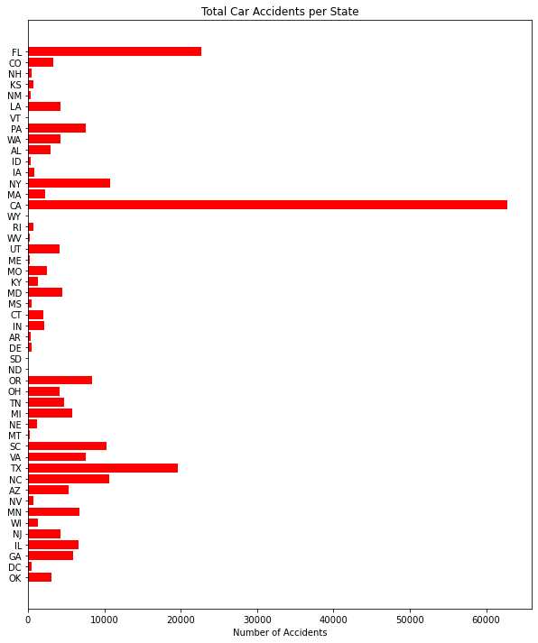

```python
plt.rcParams["figure.figsize"] = (10,12)
plt.barh(state_accidents['State'], state_accidents['Accidents'], align='center', color = 'red')
plt.title("Total Car Accidents per State")
plt.xlabel('Number of Accidents')
plt.show()
```

Looking at the bar chart above we can see that California has the highest amount of accidents (> 60000) by far compared to any other states. The states that are significantly lower than California but still have a high amount of accidents are Florida and Texas. This shows us that these states are more prone to car accidents than the rest of the states in the US.

Since the bar chart is hard to analyze in context to other states, I decided to create a chloropleth graph. Since we are looking at geographical data it is easier if we viewed it directly on the map of the US. A chloropleth graph helps us to do this. More information on creating different chloropleth graphs using folium can be found here: https://python-visualization.github.io/folium/quickstart.html

```python
#importing necessary library for the creation of the map
import folium
```

```python
#gets the files so that state codes can be associated with locations on the map
url = ("https://raw.githubusercontent.com/python-visualization/folium/master/examples/data")
state_geo = f"{url}/us-states.json"

#Creates the US map
m = folium.Map(location=[48, -102], zoom_start=4)

#Adds the information of accidents to the map
folium.Choropleth(
    geo_data=state_geo,
    name="choropleth",
    data=state_accidents,
    columns=["State", "Accidents"],
    key_on="feature.id",
    fill_color="YlGn",
    fill_opacity=0.7,
    line_opacity=0.2,
    legend_name="# of Accidents",
).add_to(m)

folium.LayerControl().add_to(m)

m
```

Make this Notebook Trusted to load map: File -> Trust Notebook

[interactive chart not shown]

Looking at the map we can see that California is the darkest shade of green across US, this shows us that California is leading with the highest amount of accidents. Compared to all the other states, the states with the light greeen shade are a little more prone to accidents. These states include Texas, Florida, North Carolina and New York. We could not notice that the latter two states also had a significant amount of accidents from our bar chart so it was a good idea to represent our data in this manner.

Note: Alaska is a shade of black on the map because we do not have any data on Alaska in our car accident data set, the black does not have anything to do with the amount of accidents in that state.

Now that we have looked at which states has the highest amount of accidents we might want to look at which states have the most severe accidents. Our dataframe has a column named 'Severity' which is a number between 1 and 4. A 1 indicates the least impact on traffic meaning the accident was not that critical whereas a 4 indicates a significant impact on traffic meaning that the accident was probably severe as it took a while for the traffic to be cleared.

Since we already have a dataframe with accumulated information about the total accidents per state, we can just modify the dataframe to have a column that holds the average severity of all the accidents that happened in that state.

```python
#creates new columns for our new dataframe
severity_per_state = []

#for every state count the number of accidents in our dataframe that happened in that state and store the average severity of those accidents
for state in states:
    match = us_accidents.loc[us_accidents['State'] == state]
    avg = np.mean(match['Severity'])
    severity_per_state.append(avg)

#adds new column to existing database
state_accidents['Avg_Severity'] = severity_per_state
```

```python
state_accidents.head()
```

|  | State | Accidents | Avg_Severity |
| --- | --- | --- | --- |
| 0 | OK | 3058 | 2.124918 |
| 1 | DC | 441 | 2.394558 |
| 2 | GA | 5886 | 2.608733 |
| 3 | IL | 6615 | 2.461527 |
| 4 | NJ | 4305 | 2.377236 |

Similar to what we did above with the total accidents per state, we can make a chloropleth graph with the average severity of the accidents per state

```python
#Creates the US map
m = folium.Map(location=[48, -102], zoom_start=4)

#Adds the information of average severity to the map
folium.Choropleth(
    geo_data=state_geo,
    name="choropleth",
    data=state_accidents,
    columns=["State", "Avg_Severity"],
    key_on="feature.id",
    fill_color="YlGn",
    fill_opacity=0.7,
    line_opacity=0.2,
    legend_name="Severity",
).add_to(m)

folium.LayerControl().add_to(m)

m
```

Make this Notebook Trusted to load map: File -> Trust Notebook

[interactive chart not shown]

From the map we can notice that there seems to be more severe accidents taking place in Wyoming as well as a bunch of other states like Georgia, Colorado, Indiana, Iowa, and Wisconsin. The color seems to be pretty evenly spread out throughout the US. An important thing to notice here is that the states that had the highest amount of total accidents do not seem to be in a deep shade of green. For example, California had a lot of accidents and was a deep shade of green on the previous map, but on this map it is a very light shade. This is similar to the other states that we discussed earlier too like Texas and Florida. This shows us that a large amount of accidents does not necessarily mean that the accidents were severe as the state with the highest accidents does not necessarily have the highest severity.

#### Population

Now that we have explored the statistics across the different states across the US, we can see if the population of the state plays an indirect role. I believe this might be important to do because most of the states that had a lot of accidents are states whose populations are large. Scaling the raw value of total accidents by the population could help reveal if the high populations are overshadowing the rest of the states.

Since we have a seperate dataframe that holds the populations of all the states and a different dataframe with the total accident values per states, we first need to join the two dataframes so that we can scale by the population. One issue with this is that the dataframe with the population has full state names but our other data frame has abbreviations. Here I attempt to fix the full state names into abbreviations using the 'us' package in python. More information on this package can be found here: https://pypi.org/project/us/

```python
import us
```

```python
#Provides a mapping between the abbreviation and the full state name
state_dict = us.states.mapping('name', 'abbr')

#For every state in the dataframe change the full state name to the abbreviation from the mapping
for ind,row in state_population.iterrows():
    state_population.loc[ind, 'State'] = state_dict.get(row['State'])
```

```python
state_population.head()
```

|  | State | Population |
| --- | --- | --- |
| 0 | CA | 39512223 |
| 1 | TX | 28995881 |
| 2 | FL | 21477737 |
| 3 | NY | 19453561 |
| 4 | PA | 12801989 |

Now that we've fixed the state names we can merge the two dataframes together and scale the total accidents by the population of the state. Similar to before we can create a chloropleth graph to understand the data better.

```python
#merging the two dataframes
state_accidents = pd.merge(state_accidents, state_population, on="State")

#calculating the accidents/population per state and storing it in a new column in the dataframe
state_accidents['Accidents_Scaled'] = state_accidents['Accidents']/state_accidents['Population']
```

```python
#Creates the US map
m = folium.Map(location=[48, -102], zoom_start=4)

#Adds the information of scaled accidents to the map
folium.Choropleth(
    geo_data=state_geo,
    name="choropleth",
    data=state_accidents,
    columns=["State", "Accidents_Scaled"],
    key_on="feature.id",
    fill_color="YlGn",
    fill_opacity=0.7,
    line_opacity=0.2,
    legend_name="accidents_scaled",
).add_to(m)

folium.LayerControl().add_to(m)

m
```

Make this Notebook Trusted to load map: File -> Trust Notebook

[interactive chart not shown]

As we can see from the map above, scaling our raw value of total accidents by the population of the state changes the shade of the color on certain states. The states with the higher population are not the only ones that have the highest amount of accidents anymore. This gives us a more accurate representation of which states have a higher amount of accidents like Oregon and South Carolina.

#### Weather

As a driver, driving in bad weather conditions is not always the greatest idea thus exploring if there is a relationship between the number of accidents and the weather and the severity of the accidents itself can be helpful.

We will first analyze in what weather conditions did most of the car accidents take place in.

```python
#Remove duplicates of all the different weather conditions in the dataframe
weather = list(set(us_accidents['Weather_Condition'].dropna()))

#Stores the number of accidents that happened under corresponding weather condition
accident_by_weather = []

#for every weather condition counts the number of accidents that happened under it
for w in weather:
    match = us_accidents.loc[us_accidents['Weather_Condition'] == w]
    accident_by_weather.append(len(match))
```

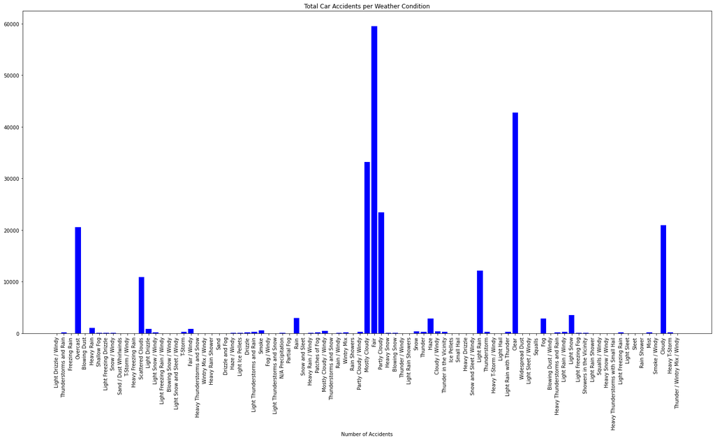

```python
plt.rcParams["figure.figsize"] = (25,12)
plt.bar(weather, accident_by_weather, align='center', color = 'blue')
plt.xticks(rotation=90)
plt.title("Total Car Accidents per Weather Condition")
plt.xlabel('Number of Accidents')
plt.show()
```

Looking at the bar plot above we can see that a lot of car accidents occured when it was clear or fair outside. This was highly unexpected! When one thinks of driving in bad weather one would expect to have more driving accidents during worse weather like when its snowing or there is ice on the roads. However it is surprising that this is not the case. Although, a lot of the other accidents took place in cloudy and overcast weather as well as some rain. This data is more expected as it shows that driving in cloudy or rainy weather might mean that one is more likely to get into an accident compared to other weather conditions. Although, one is equally or more likely to get into an accident if the weather is clear or fair too.

Now that we have looked at what weather conditions did most of the car accidents take place in, we can also look at the severity of the accidents. So, we want to understand if worse weather conditions are related to the severity of the accident itself.

```python
#Stores the average severity for accidents that happened under the weather condition
severity_by_weather = []

#for every weather condition stores the average severity of the accidents that happened under it
for w in weather:
    match = us_accidents.loc[us_accidents['Weather_Condition'] == w]
    avg = np.mean(match['Severity'])
    severity_by_weather.append(avg)
```

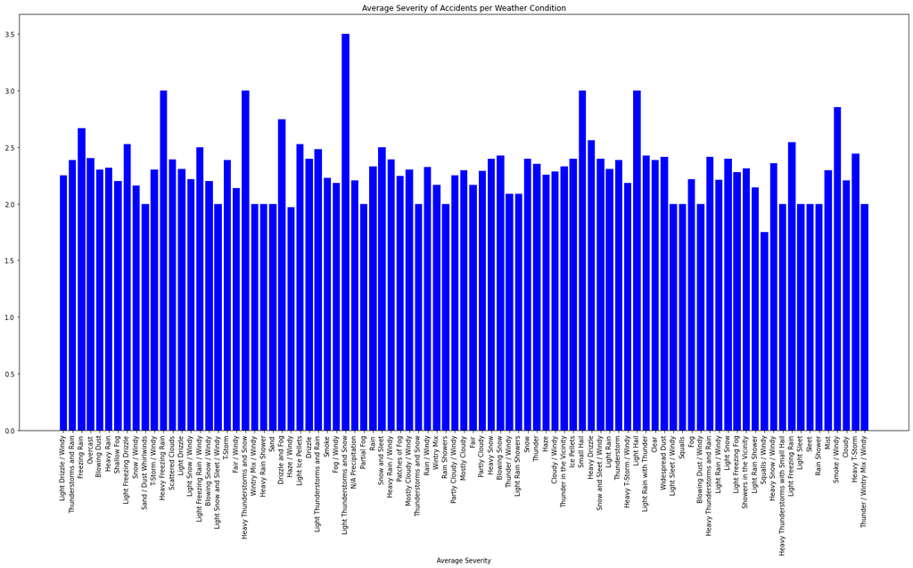

```python
plt.rcParams["figure.figsize"] = (25,12)
plt.bar(weather, severity_by_weather, align='center', color = 'blue')
plt.xticks(rotation=90)
plt.title("Average Severity of Accidents per Weather Condition")
plt.xlabel('Average Severity')
plt.show()
```

```python
#Average severity of all accidents
np.mean(us_accidents['Severity'])
```

```
2.288284
```

Overall, analyzing the accidents that happened under certain weather conditions showed us that the number of accidents might not be affected by how bad the weather is but the severity of the accident is to a certain extent influenced by how bad the weather condition is when the accident took place.

#### Time

In this section, I try to analyze the trend in car accidents over time. Since the data spans from 2016 to 2020 we can try to get an idea of whether the number of car accidents increased over time, deacreased or remained about the same.

```python
#The data spans from 2016 to 2020
years = np.arange(2016,2021)
```

```python
#Find the number of accidents in the dataset that happened every year
accidents_per_year = []
for y in years:
    match = us_accidents.loc[us_accidents['Start_Time'].dt.year == y]
    accidents_per_year.append(len(match))
```

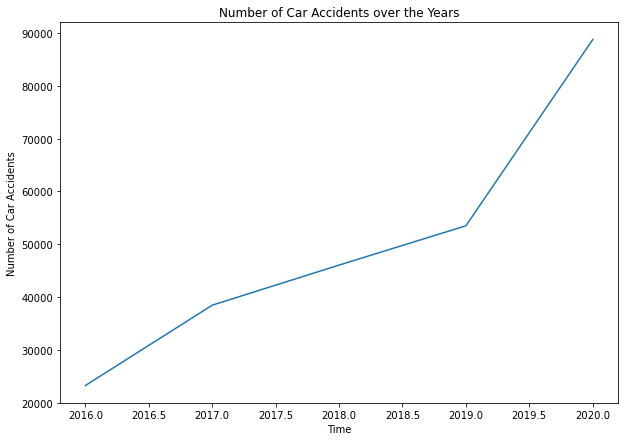

```python
plt.rcParams["figure.figsize"] = (10,7)
plt.plot(np.arange(2016,2021), accidents_per_year)
plt.title("Number of Car Accidents over the Years")
plt.xlabel("Time")
plt.ylabel("Number of Car Accidents")
plt.show()
```

According to the graph above we can see that there has been an increase in accidents since 2016. From 2016 to 2019 there was a steady increase in the number of car accidents but from 2019 to 2020 there was a huge jump in the increase of cases. This is apparent from the slope of the line at the certain intervals.

We can see that the number of accidents have been increasing over the years but to take a closer look we can also plot the number of accidents per month over the years.

```python
#There are 12 months in a year
months = np.arange(1,13)

#For every month in the year count how many accidents happened
accidents_per_month = []
for m in months:
    match = us_accidents.loc[us_accidents['Start_Time'].dt.month == m]
    temp = []
    for y in years:
        match_updated = match.loc[match['Start_Time'].dt.year == y]
        temp.append(len(match_updated))

    accidents_per_month.append(temp)
```

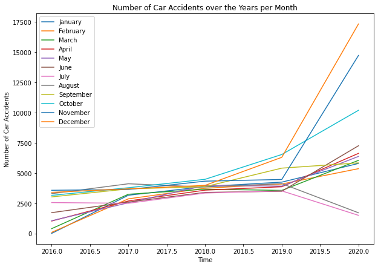

```python
#Plotting the number of car accidents that happened every month over the years 2016 to 2020
i = 0
month_labels = ['January', 'February', 'March', 'April', 'May', 'June', 'July', 'August', 'September', 'October', 'November', 'December']
for x in accidents_per_month:
    plt.plot(np.arange(2016,2021), x, label = month_labels[i])
    i += 1

plt.rcParams["figure.figsize"] = (10,7)
plt.title("Number of Car Accidents over the Years per Month")
plt.xlabel("Time")
plt.ylabel("Number of Car Accidents")
plt.legend()
plt.show()
```

#### Day or Night?

We have looked at many variables so far that might have an affect on the number of accidents happening across the US but the one thing we have not considered is whether there were more accidents happening during the day time or during the night.

Earlier we converted one of our columns in the dataframe to a boolean variable that is true if the accident happened during the day and false if it happened during the night. We will now use this to count how many accidents occcured during the day and how many occured during the night; we can plot this in a form of a pie chart.

```python
#Counting how many accidents happened during the day or night
count_day = len(us_accidents.loc[us_accidents['is_day'] == True])
count_night = len(us_accidents.loc[us_accidents['is_day'] == False])
```

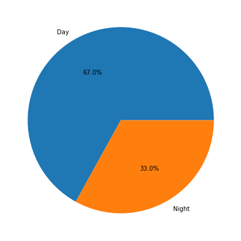

```python
plt.pie([count_day, count_night], labels = ['Day', 'Night'], autopct='%1.1f%%')
plt.show()
```

As can be seen from the pie chart, more car accidents took place during the day than they did at night. I thought this was unexpected because the visibility at night would be lower which could lead to more accidents but this is not true according to our data.

Throughout this part of the project we have explored different factors that could be affecting the severity of the accidents as well as the number of accidents in general. We have also seen some increasing trends in the number of car accidents over the years, but now we can move on to the machine learning portion where we can try to build a model to learn exactly how these variables influence the car accidents.

### 4. Machine Learning

In the previous part we focused on using visualizations to figure out if there was any relationship between certain variables and the number of accidents taking place as well as the severity of these accidents. However, in this portion we will try to see how the categorical variables in our dataset can have an affect on the severity of the car accident. I decided to focus on severity because trying to predict how severe an accident can be based on categorical variables might be helpful as this way pplicy changes can be made to avoid bad car accidents based on the variables.

First we can take a look at the correlation between each column in our dataframe to get a better look at which columns are affected by each other. The Seaborn library in python makes this really easy as it allows us to generate a correlation matrix for our dataframe.

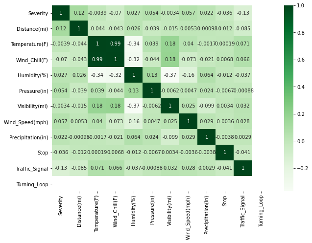

```python
import seaborn as sns
sns.heatmap(us_accidents.corr(), annot=True, cmap='Greens')
```

Here we can see the correlation between different columns that have numerical values. To interpret the heatmap one can focus on the shade of the color so if the green is dark that means that the correlation is high while lower shades mean the correlation is low. Although the diagnols should not be confused with the highest correlation because they represent the relationship between a variable and itself. The relationship between a variable and itself will be high thus the dark green shade and the number 1 as well.

Looking at the matrix, there is not much of a correlation that stands out between the numerical variables. Most of them have have light shades of green and it is unclear whether a strong relationship between the variables exists.

Instead of the numerical variables we can try to see if there is a relationship between severity and any of the categorical variables in our dataframe like wind direction or weather condition. Since we have multiple categorical variables to focus on and one dependent variable of severity we can use multiple linear regression and see if that model fits well to our data.

In order to do this with our categorical variables, we need to convert them into labels first. This basically means that every entry in the dataframe with the same value will be put into the same category. Python has a label encoder that takes care of this for us in the sklearn library. When trying to find functions that did this I found this article to be helpful: https://towardsdatascience.com/categorical-encoding-using-label-encoding-and-one-hot-encoder-911ef77fb5bd. It also explains why I chose to use the label encoding

```python
from sklearn.preprocessing import LabelEncoder
```

```python
#Creates copy of the dataframe so that we dont loose the original
copy_df = us_accidents.copy()
```

```python
#Converts datatypes of these columns to strings so that label encoding can be done
copy_df.Wind_Direction = copy_df.Wind_Direction.astype(str)
copy_df.Weather_Condition = copy_df.Weather_Condition.astype(str)
```

```python
#Makes a label encoder object and encodes all the categorical variables
label_encoder = LabelEncoder()
variables = ['State', 'Wind_Direction','Weather_Condition', 'Stop', 'Traffic_Signal', 'is_day']

for column in categorical:
    copy_df[column] = le.fit_transform(copy_df[column])
```

```python
#Stores all the independent variables in a seperate dataframe
ind_variable = copy_df.loc[:, ['State', 'Wind_Direction','Weather_Condition', 'Stop', 'Traffic_Signal', 'is_day']]
```

```python
#Performing the multi regression fit on the data
import statsmodels.api as sm
ols_model = sm.OLS(copy_df['Severity'], ind_variable).fit()
ols_model.summary()
```

OLS Regression Results

| Dep. Variable: | Severity | R-squared (uncentered): | 0.812 |
| --- | --- | --- | --- |
| Model: | OLS | Adj. R-squared (uncentered): | 0.812 |
| Method: | Least Squares | F-statistic: | 1.800e+05 |
| Date: | Fri, 14 May 2021 | Prob (F-statistic): | 0.00 |
| Time: | 12:13:33 | Log-Likelihood: | -3.5986e+05 |
| No. Observations: | 250000 | AIC: | 7.197e+05 |
| Df Residuals: | 249994 | BIC: | 7.198e+05 |
| Df Model: | 6 |  |  |
| Covariance Type: | nonrobust |  |  |

|  | coef | std err | t | P>\|t\| | [0.025 | 0.975] |
| --- | --- | --- | --- | --- | --- | --- |
| State | 0.0255 | 0.000 | 211.392 | 0.000 | 0.025 | 0.026 |
| Wind_Direction | 0.0512 | 0.000 | 206.039 | 0.000 | 0.051 | 0.052 |
| Weather_Condition | 0.0120 | 8.02e-05 | 149.450 | 0.000 | 0.012 | 0.012 |
| Stop | 0.1839 | 0.017 | 11.135 | 0.000 | 0.152 | 0.216 |
| Traffic_Signal | 0.0544 | 0.006 | 9.737 | 0.000 | 0.043 | 0.065 |
| is_day | 0.7896 | 0.004 | 197.005 | 0.000 | 0.782 | 0.797 |

| Omnibus: | 3230.462 | Durbin-Watson: | 1.788 |
| --- | --- | --- | --- |
| Prob(Omnibus): | 0.000 | Jarque-Bera (JB): | 3353.336 |
| Skew: | 0.282 | Prob(JB): | 0.00 |
| Kurtosis: | 2.946 | Cond. No. | 351. |

Notes:  
[1] R² is computed without centering (uncentered) since the model does not contain a constant.  
[2] Standard Errors assume that the covariance matrix of the errors is correctly specified.

Looking at the summary function our r^2 value is 0.812. This is quite high and means that about 81% of the variance in severity can be explained by the different independent variables that we focused on. Looking at the coefficients themselves, some of them are relatively low like State, Wind_Direction and Weather_Condition. This shows us that these variables might not influence the severity of the accident that much. However the variables that had a larger coefficient were Stop and is_day. This shows us that the presence of a stop sign near the accident can have an impact on how severe the accident is and the time of day that the accident occurs in can also influence the severity of the accident.

### 5. Conclusion

The goal of this project was to see what factors influence the large number of car accidents that happen in the United States every year. Throughout the project we went through the different steps of the data science pipeline and discovered various factors that might influence the car accidents and the severity of the accident itself.

Overall, we have identified plenty of factors like weather condition and time of day that can influence car accidents taking place across the United States. However, these factors are just a small subset of what could be influencing the accidents. One potential factor we did not consider was seat belts and if they were being worn. This factor could also influence the severity of the accident. Thus, although we have identified some factors there is a lot of potential work to be done in order to fully understand car accidents and try to see if potential action can be taken to save someone's life.